# PREDICT: GSEA in RISK and E-MTAB-7604 cohorts

Veronika Niederlova

6/14/2021

In this notebook, we provide the code to perform GSEA analysis of markers of the most severe Crohn’s disease from the PREDICT cohort in two other cohorts: RISK cohort and Belgium cohort. Data of RISK cohort were obtained from the [github repository](https://github.com/effiken/martin_et_al_cell_2019) associated with the study `Single-Cell Analysis of Crohn’s Disease Lesions Identifies a Pathogenic Cellular Module Associated with Resistance to Anti-TNF Therapy` by Martin et al., Cell, 2019. Data from the Belgium cohort were obtained from Array-Express under the accession number [E-MTAB-7604](https://www.ebi.ac.uk/arrayexpress/experiments/E-MTAB-7604/).

The analysis has three main steps:

1. Select markers from PREDICT cohort.
2. Load and process the data from RISK cohort.
3. Load and process the data from E-MTAB-7604 cohort.

# PART 1: Prepare data from PREDICT cohort

```r
# seu <- readRDS(path_predict_seu)

markers_state <- as.data.frame(read_delim(paste0(path_data,"Supp_tables/CD14_03_cellstate_markerstop50sig.tsv"), "\t", escape_double = FALSE, trim_ws = TRUE))


top_pos_pc2 <-  paste0("CD.",c("T.MT-CO2.MT-CO1","EC.GNAT3.TRPM5","EC.RBP2.CYP3A4","cDC2.CLEC10A.FCGR2B","Myeloid.MKI67.IGKC","Goblet.FCGBP.HES6","EC.ADH1C.EDN1","Mcell.CSRP2.SPIB","EC.FABP6.PLCG2","EC.MTRNR2L1.MT-ND3","T.MT-CO2.CCR7","EC.ADH1C.RPS4Y1","T.IFI44L.PTGER4","cDC2.CD1C.NDRG2","Goblet.FCGBP.ITLN1","EC.FABP1.ADIRF","EC.GSTA2.TMPRSS15","cDC2.CLEC10A.CD1E","Mac.CXCL8.HES1","cDC2.CD1C.CD207","Mono/cDC2.CLEC10A.SDS","T.LAG3.BATF","Secretory.GSTA1.REG1B","EC.ADH1C.GSTA1","EpithStem.LINC00176.RPS4Y1"))

top_neg_pc2 <-  paste0("CD.",c(
  "Mono.FCN1.LYST","NK.MKI67.GZMA","Mono.CXCL10.TNF","T.CARD16.GB2","Mono.FCN1.S100A4","Mono/Mac.CXCL10.CXCL11","NK.GNLY.GZMB","EC.OLFM4.MT-ND2","NK.GNLY.IFNG","T.MKI67.IL22","NK.GNLY.FCER1G","Mac/DC.CXCL10.CLEC4E","T.MKI67.IFNG","T.MKI67.FOXP3","Mono/Mac.CXCL10.FCN1","T.GNLY.CSF2","EC.NUPR1.LCN2","Mac.CXCL3.APOC1","pDC.IRF7.IL3RA","Mono.CXCL3.FCN1","Mac.C1QB.CD14","Goblet.RETNLB.ITLN1","T.CCL20.RORA","T.MAF.CTLA4","cDC2.CD1C.AREG"))

kableExtra::kable(data.frame(PC2_top25_neg = top_neg_pc2[order(top_neg_pc2)],
                             PC2_top25_pos = top_pos_pc2[order(top_pos_pc2)])) %>%
  kable_styling(full_width = F, font_size = 10, bootstrap_options = c("hover", "condensed", "responsive")) %>%  column_spec(1:2, background = "white", color = "black")
```

| PC2_top25_neg | PC2_top25_pos |
| --- | --- |
| CD.cDC2.CD1C.AREG | CD.cDC2.CD1C.CD207 |
| CD.EC.NUPR1.LCN2 | CD.cDC2.CD1C.NDRG2 |
| CD.EC.OLFM4.MT-ND2 | CD.cDC2.CLEC10A.CD1E |
| CD.Goblet.RETNLB.ITLN1 | CD.cDC2.CLEC10A.FCGR2B |
| CD.Mac.C1QB.CD14 | CD.EC.ADH1C.EDN1 |
| CD.Mac.CXCL3.APOC1 | CD.EC.ADH1C.GSTA1 |
| CD.Mac/DC.CXCL10.CLEC4E | CD.EC.ADH1C.RPS4Y1 |
| CD.Mono.CXCL10.TNF | CD.EC.FABP1.ADIRF |
| CD.Mono.CXCL3.FCN1 | CD.EC.FABP6.PLCG2 |
| CD.Mono.FCN1.LYST | CD.EC.GNAT3.TRPM5 |
| CD.Mono.FCN1.S100A4 | CD.EC.GSTA2.TMPRSS15 |
| CD.Mono/Mac.CXCL10.CXCL11 | CD.EC.MTRNR2L1.MT-ND3 |
| CD.Mono/Mac.CXCL10.FCN1 | CD.EC.RBP2.CYP3A4 |
| CD.NK.GNLY.FCER1G | CD.EpithStem.LINC00176.RPS4Y1 |
| CD.NK.GNLY.GZMB | CD.Goblet.FCGBP.HES6 |
| CD.NK.GNLY.IFNG | CD.Goblet.FCGBP.ITLN1 |
| CD.NK.MKI67.GZMA | CD.Mac.CXCL8.HES1 |
| CD.pDC.IRF7.IL3RA | CD.Mcell.CSRP2.SPIB |
| CD.T.CARD16.GB2 | CD.Mono/cDC2.CLEC10A.SDS |
| CD.T.CCL20.RORA | CD.Myeloid.MKI67.IGKC |
| CD.T.GNLY.CSF2 | CD.Secretory.GSTA1.REG1B |
| CD.T.MAF.CTLA4 | CD.T.IFI44L.PTGER4 |
| CD.T.MKI67.FOXP3 | CD.T.LAG3.BATF |
| CD.T.MKI67.IFNG | CD.T.MT-CO2.CCR7 |
| CD.T.MKI67.IL22 | CD.T.MT-CO2.MT-CO1 |

We will select top 10 markers of each of these clusters. The selection is based on rank score function (see Methods). Duplicate hits are only counted once and genes that appear as hits for both positive and negative PC2 clusters are filtered out.

The final gene list for PC2_top25_neg contains 92 genes:

```r
markers_top_neg_pcs <- markers_state %>% dplyr::filter(cluster %in% c(top_neg_pc2))
markers_top_pos_pcs <- markers_state %>% dplyr::filter(cluster %in% c(top_pos_pc2))

markers_top_neg_pcs <- rank_score_func(markers_top_neg_pcs)
markers_top_pos_pcs <- rank_score_func(markers_top_pos_pcs)

markers_top_neg_pcs <-  markers_top_neg_pcs %>% group_by(cluster) %>% slice_max(order_by = score, n = 10)
markers_top_pos_pcs <- markers_top_pos_pcs %>% group_by(cluster) %>% slice_max(order_by = score, n = 10)

markers_top_neg_pcs_genes <- unique(markers_top_neg_pcs$gene)
markers_top_pos_pcs_genes <- unique(markers_top_pos_pcs$gene)

markers_top_neg_pcs_genes_filt <- markers_top_neg_pcs_genes[which(markers_top_neg_pcs_genes %in% markers_top_pos_pcs_genes == F)]
markers_top_pos_pcs_genes_filt <- markers_top_pos_pcs_genes[which(markers_top_pos_pcs_genes %in% markers_top_neg_pcs_genes == F)]

knitr::kable(matrix(c(markers_top_neg_pcs_genes_filt[order(markers_top_neg_pcs_genes_filt)], rep("",4)), ncol = 8)) %>%
  kable_styling(full_width = F, font_size = 10,bootstrap_options = c("hover", "condensed", "responsive")) %>%  column_spec(1:8, background = "white", color = "black")
```

| AC092580.4 | CD86 | CXCL9 | GBP1 | IL3RA | MYOM2 | REG3A | TK1 |
| --- | --- | --- | --- | --- | --- | --- | --- |
| ADA | CENPF | CXCR6 | GNLY | KLRC1 | NKG7 | RORA | TNF |
| APOBEC3A | CHN1 | DLGAP5 | GPNMB | KLRD1 | NUSAP1 | RP11-1143G9.4 | TNFAIP6 |
| APOC1 | CLEC4E | EREG | GZMA | KLRF1 | OLR1 | RRM2 | TOP2A |
| ASPM | CLIC3 | FAM26F | GZMB | LCN2 | PLA2G2A | RTKN2 | TRDC |
| BIRC5 | CSF2 | FCGR1A | GZMH | LILRA4 | PLA2G7 | S100A4 | TYMS |
| C1QB | CTLA4 | FCGR3A | ICOS | LINC01272 | PLAUR | S100A8 | XCL1 |
| C5AR1 | CTSW | FCN1 | IFNG | MAF | PRF1 | S100A9 | XCL2 |
| CCL3 | CX3CR1 | FGFBP2 | IL1RN | MIR4435-2HG | PRSS2 | SCT |  |
| CCL4L2 | CXCL10 | FGL2 | IL26 | MKI67 | PTCRA | SERPINA1 |  |
| CD14 | CXCL11 | FOXP3 | IL2RB | MS4A4A | PTPRS | SMPD3 |  |
| CD163 | CXCL3 | FXYD3 | IL32 | MYBL2 | PYHIN1 | TIGIT |  |

The final gene list for PC2_top25_pos contains 103 genes:

```r
knitr::kable(matrix(c(markers_top_pos_pcs_genes_filt[order(markers_top_pos_pcs_genes_filt)], ""), ncol = 8)) %>%
  kable_styling(full_width = F, font_size = 10,bootstrap_options = c("hover", "condensed", "responsive")) %>%  column_spec(1:8, background = "white", color = "black")
```

| AC017002.1 | CCL15 | CLSPN | G0S2 | KRT8 | MT-ND1 | PTGR1 | SMIM22 |
| --- | --- | --- | --- | --- | --- | --- | --- |
| AC020571.3 | CCL25 | CMYA5 | GNAT3 | LAG3 | MT-ND2 | PTPRC | STARD10 |
| ACE | CCR7 | COL27A1 | GNG13 | MALAT1 | MT-ND3 | RAMP1 | STMN1 |
| ADH1C | CD1C | CSF2RA | GSTA1 | MAOA | MT-ND4 | RBP2 | TFF3 |
| ADIRF | CD1D | CXCR4 | GSTA2 | MEP1A | MT1H | RP11-295M3.4 | TNFAIP3 |
| AGR3 | CD207 | DHRS11 | GUCA2A | MIAT | MT1M | S100A14 | TNFRSF1B |
| AKR1C3 | CD3E | DNASE1L3 | HES6 | MIR194-2HG | MTRNR2L1 | SDS | TRAC |
| ANPEP | CDC42EP5 | EDN1 | IFI44L | MT-ATP6 | MTRNR2L12 | SELENBP1 | TRAT1 |
| ANXA1 | CDHR5 | FABP1 | IGFBP2 | MT-ATP8 | MTRNR2L8 | SFN | TRPM5 |
| APOB | CDX1 | FABP2 | IL17RB | MT-CO1 | MTTP | SH2D6 | TUBA1B |
| B2M | CENPU | FABP6 | KLF5 | MT-CO2 | PLCG2 | SH2D7 | VSIG4 |
| BMX | CHP2 | FCER1A | KRT19 | MT-CO3 | PPP1R1B | SLC2A3 | ZG16 |
| C19orf33 | CLEC2D | FERMT1 | KRT20 | MT-CYB | PRAP1 | SLC5A1 |  |

# PART 2: RISK cohort

To load data from RISK cohort, please download the `bulk_data.rd` file from [this github repository](https://github.com/effiken/martin_et_al_cell_2019). The path to the file in the repository is `martin_et_al_cell_2019/input/external_cohorts_data/bulk_data.rd`. For convenience, we also provide this file together with our code. We assume that this file is stored in the `/data/RISK/` folder.

## Load and extract data

Let’s load the file and filter participants from RISK cohort, whose info about the outcome of anti-TNF treatment is available.

```r
martin_bulk_data <- load(paste0(path_data,"RISK/bulk_data.rd"))

# Metadata are stored in the slot design
bulk_metadata <- bulk$design

# Count matrix is stored in the slot raw
bulk_matrix <- bulk$raw

# Filtering - only genes with reported expression and only RISK patients with anti-TNF response info
bulk_risk_response_names <- rownames(bulk_metadata %>% dplyr::filter(is.na(response)==F))
bulk_matrix_filt <- bulk_matrix[which(is.na(rowSums(bulk_matrix))==F),which(colnames(bulk_matrix) %in% bulk_risk_response_names)]


response <- bulk_metadata$response
names(response) <- rownames(bulk_metadata)

response_filt <- response[which(names(response) %in% colnames(bulk_matrix_filt))]
response_filt <- response_filt[match(names(response_filt),colnames(bulk_matrix_filt))]
```

## Calculate fold changes using Seurat

Because the input data is already FKPM normalized and DESeq2 requires raw counts as input, we will use Seurat for FoldChange calculation.

```r
# Create Seurat object and add response metadata
RISK_seurat <- CreateSeuratObject(bulk_matrix_filt)
RISK_seurat <- AddMetaData(RISK_seurat, response_filt, col.name = "response")

# Calculate fold changes for all genes in responders vs. non-responders
Idents(RISK_seurat) <- RISK_seurat$response
fc_risk_seurat <- FoldChange(RISK_seurat, ident.1 = "R", ident.2 = "NR")

# The calculated fold changes will be used as input for GSEA
fc_risk_seurat.input <- as.numeric(fc_risk_seurat$avg_log2FC)
names(fc_risk_seurat.input) <- rownames(fc_risk_seurat)
fc_risk_seurat.input <- fc_risk_seurat.input[which(!is.na(fc_risk_seurat.input))]

# Prerank genes with similar fold change
set.seed(123)
fc_risk_seurat.input <- fc_risk_seurat.input[rank(fc_risk_seurat.input,  ties.method = "random")]
```

## Plot GSEA results

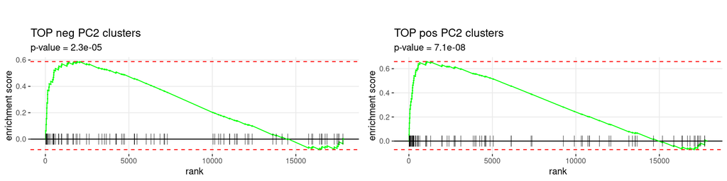

```r
fgseaRes_risk_neg <- fgsea(pathways = list(our_list = markers_top_neg_pcs_genes_filt),
                           stats = fc_risk_seurat.input)

p1 <- plotEnrichment(markers_top_neg_pcs_genes_filt, fc_risk_seurat.input) + labs(title="\n\nTOP neg PC2 clusters", subtitle = paste0("p-value = ",format.pval(fgseaRes_risk_neg$pval, digits = 2)))


fgseaRes_risk_pos <- fgsea(pathways = list(our_list = markers_top_pos_pcs_genes_filt),
                           stats    = fc_risk_seurat.input)

p2 <- plotEnrichment(markers_top_pos_pcs_genes_filt, fc_risk_seurat.input) + labs(title="\n\nTOP pos PC2 clusters", subtitle = paste0("p-value = ",format.pval(fgseaRes_risk_pos$pval, digits = 2)))

cowplot::plot_grid(p1,p2)
```

# PART 3: DATASET E_MTAB_7604

The second dataset can be obtained from Array-Express under the accession number [E-MTAB-7604](https://www.ebi.ac.uk/arrayexpress/experiments/E-MTAB-7604/). It should be unpacked and stored in the folder `data/E_MTAB_7604/`.

## Load and merge data

We will load counts of all provided patients and bind them into a gene expression matrix. The cohort contains samples from different locations and also from patients with different treatments:

```r
emtab_7604 <- c('GC058859', 'GC058865', 'GC058866', 'GC058872', 'GC058874', 'GC058911', 'GC050149', 'GC050152',
                'GC050158', 'GC050162', 'GC050173', 'GC050174', 'GC050260', 'GC050265', 'GC050272', 'GC050281', 'GC050282', 'GC050312', 'GC050318', 'GC050320', 'GC050321', 'GC050322', 'GC058827', 'GC058833', 'GC058835', 'GC058840', 'GC058849', 'GC058851', 'GC058889', 'GC058897', 'GC058904', 'GC058910', 'GC049971', 'GC049992', 'GC049997', 'GC049998', 'GC050011', 'GC050016', 'GC050024', 'GC050040', 'GC050130', 'GC050131', 'GC050193')

# Load raw counts from all patients and construct a dataframe
df <- data.frame(gene = "")
for(j in emtab_7604){
  k <-  read_tsv(paste0(path_data,"E_MTAB_7604/",j,".count"), col_names = FALSE,
                 trim_ws = TRUE)
  df_temp <- data.frame(gene = k$X1, value = k$X2)
  colnames(df_temp)[2] <- j
  df <- right_join(df, df_temp, by = "gene")
}

# Convert dataframe to matrix
mtx <- as.matrix(df %>% dplyr::select(-gene))
rownames(mtx) <- df$gene
```

```r
# Load metadata
E_MTAB_7604_sdrf <- read_delim(paste0(path_data,"E_MTAB_7604/E-MTAB-7604.sdrf.txt"),
                               "\t", escape_double = FALSE, trim_ws = TRUE)

md_emtab_7604 <- as.data.frame(E_MTAB_7604_sdrf)
md_emtab_7604$patient <- substr(md_emtab_7604$`Source Name`,1,8)
md_emtab_7604 <- data.frame(patient = md_emtab_7604$patient,
                            treatment = md_emtab_7604$`Factor Value[treatment]`,
                            response = md_emtab_7604$`Characteristics[clinical history]`,
                            site = md_emtab_7604$`Characteristics[organism part]`)

# Counts of patients in the dataset
knitr::kable(md_emtab_7604 %>% group_by(treatment, response, site) %>% tally()) %>%
  kable_styling(full_width = F, font_size = 10,bootstrap_options = c("hover", "condensed", "responsive")) %>%  column_spec(1:4, background = "white", color = "black")
```

[output not shown]

For the next analyses, we will separate samples from ileum and from colon.

## Ileum

### Create DESeq object and calculate fold changes

```r
# Prepare DeSeq input
patients.ileum <- (md_emtab_7604 %>% dplyr::filter(site == "ileum"))$patient
mtx.ileum <- mtx[,which(colnames(mtx) %in% patients.ileum)]
featureData <- data.frame(gene=rownames(mtx.ileum))

# Response metadata
ileum.response <- c(md_emtab_7604 %>% dplyr::filter(patient %in% colnames(mtx.ileum)))$response
names(ileum.response) <- c(md_emtab_7604 %>% dplyr::filter(patient %in% colnames(mtx.ileum)))$patient
ileum.response <- ileum.response[match(colnames(mtx.ileum),names(ileum.response))]

coldata <- data.frame(sample_type = factor(if_else(ileum.response == "responder","R","NR"),
                                           levels = c("R","NR")))

# Create a DESeq dataset

dds.ileum <- DESeq2::DESeqDataSetFromMatrix(countData = mtx.ileum,
                                            colData = coldata,
                                            design= ~ sample_type)

rownames(dds.ileum) <- featureData$gene

# Run DESeq2
dds.ileum <- DESeq(dds.ileum)
dds.ileum
```

```
## class: DESeqDataSet
## dim: 56643 17
## metadata(1): version
## assays(6): counts mu ... replaceCounts replaceCooks
## rownames(56643): 5S_rRNA 7SK ... __not_aligned __alignment_not_unique
## rowData names(23): baseMean baseVar ... maxCooks replace
## colnames(17): GC058865 GC058866 ... GC050024 GC050040
## colData names(3): sample_type sizeFactor replaceable
```

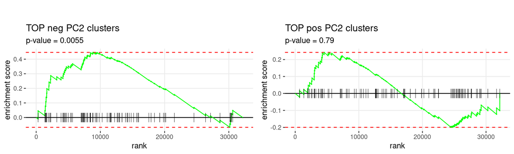

```r
# Retrieve the results
res.ileum <- results(dds.ileum)
res.ileum_df <- data.frame(gene = rownames(res.ileum),
                           pval = res.ileum@listData$pvalue,
                           logfc = res.ileum@listData$log2FoldChange,
                           padj = res.ileum@listData$padj)

# Prepare GSEA input
fc_emtab7604_ileum.input <- as.numeric(res.ileum_df$logfc)
names(fc_emtab7604_ileum.input) <- res.ileum_df$gene
fc_emtab7604_ileum.input <- fc_emtab7604_ileum.input[which(!is.na(fc_emtab7604_ileum.input))]

# Prerank genes with similar FC
set.seed(123)
fc_emtab7604_ileum.input <- fc_emtab7604_ileum.input[rank(fc_emtab7604_ileum.input,  ties.method = "random")]

# Run GSEA Top PC2 neg markers
fgseaRes_emtab7604_ileum_neg <- fgsea(pathways = list(our_list = markers_top_neg_pcs_genes_filt),
                                      stats    = fc_emtab7604_ileum.input)


p3 <- plotEnrichment(markers_top_neg_pcs_genes_filt, fc_emtab7604_ileum.input) + labs(title="\n\nTOP neg PC2 clusters", subtitle = paste0("p-value = ",format.pval(fgseaRes_emtab7604_ileum_neg$pval, digits = 2)))

# Run GSEA Top PC2 pos markers

fgseaRes_emtab7604_ileum_pos <- fgsea(pathways = list(our_list = markers_top_pos_pcs_genes_filt),
                                      stats    = fc_emtab7604_ileum.input)

p4 <- plotEnrichment(markers_top_pos_pcs_genes_filt, fc_emtab7604_ileum.input) + labs(title="\n\nTOP pos PC2 clusters", subtitle = paste0("p-value = ",format.pval(fgseaRes_emtab7604_ileum_pos$pval, digits = 2)))

cowplot::plot_grid(p3,p4)
```

## Colon

### Create DESeq object and calculate fold changes

```r
# Prepare DeSeq input
patients.colon <- (md_emtab_7604 %>% dplyr::filter(site == "colon"))$patient
mtx.colon <- mtx[,which(colnames(mtx) %in% patients.colon)]
featureData <- data.frame(gene=rownames(mtx.colon))

# Response metadata
colon.response <- c(md_emtab_7604 %>% dplyr::filter(patient %in% colnames(mtx.colon)))$response
names(colon.response) <- c(md_emtab_7604 %>% dplyr::filter(patient %in% colnames(mtx.colon)))$patient
colon.response <- colon.response[match(colnames(mtx.colon),names(colon.response))]

coldata <- data.frame(sample_type = factor(if_else(colon.response == "responder","R","NR"),
                                           levels = c("R","NR")))

# Create a DESeq dataset

dds.colon <- DESeq2::DESeqDataSetFromMatrix(countData = mtx.colon,
                                            colData = coldata,
                                            design= ~ sample_type)

rownames(dds.colon) <- featureData$gene

# Run DESeq2
dds.colon <- DESeq(dds.colon)
dds.colon
```

```
## class: DESeqDataSet
## dim: 56643 26
## metadata(1): version
## assays(6): counts mu ... replaceCounts replaceCooks
## rownames(56643): 5S_rRNA 7SK ... __not_aligned __alignment_not_unique
## rowData names(23): baseMean baseVar ... maxCooks replace
## colnames(26): GC058859 GC058874 ... GC050131 GC050193
## colData names(3): sample_type sizeFactor replaceable
```

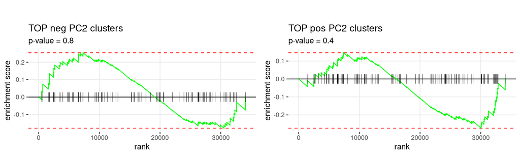

```r
# Retrieve the results
res.colon <- results(dds.colon)
res.colon_df <- data.frame(gene = rownames(res.colon),
                           pval = res.colon@listData$pvalue,
                           logfc = res.colon@listData$log2FoldChange,
                           padj = res.colon@listData$padj)

# Prepare GSEA input
fc_emtab7604_colon.input <- as.numeric(res.colon_df$logfc)
names(fc_emtab7604_colon.input) <- res.colon_df$gene
fc_emtab7604_colon.input <- fc_emtab7604_colon.input[which(!is.na(fc_emtab7604_colon.input))]

# Prerank genes with similar FC
set.seed(123)
fc_emtab7604_colon.input <- fc_emtab7604_colon.input[rank(fc_emtab7604_colon.input,  ties.method = "random")]


# Run GSEA Top PC2 neg markers
fgseaRes_emtab7604_colon_neg <- fgsea(pathways = list(our_list = markers_top_neg_pcs_genes_filt),
                                      stats    = fc_emtab7604_colon.input)


p5 <- plotEnrichment(markers_top_neg_pcs_genes_filt, fc_emtab7604_colon.input) + labs(title="\n\nTOP neg PC2 clusters", subtitle = paste0("p-value = ",format.pval(fgseaRes_emtab7604_colon_neg$pval, digits = 2)))

# Run GSEA Top PC2 pos markers

fgseaRes_emtab7604_colon_pos <- fgsea(pathways = list(our_list = markers_top_pos_pcs_genes_filt),
                                      stats    = fc_emtab7604_colon.input)

p6 <- plotEnrichment(markers_top_pos_pcs_genes_filt, fc_emtab7604_colon.input) + labs(title="\n\nTOP pos PC2 clusters", subtitle = paste0("p-value = ",format.pval(fgseaRes_emtab7604_colon_pos$pval, digits = 2)))

cowplot::plot_grid(p5,p6)
```

# Save the plots

```r
p_final <- cowplot::plot_grid(
  cowplot::plot_grid(p1, p2, ncol = 2),
  cowplot::plot_grid(p3, p4, ncol = 2),
  cowplot::plot_grid(p5, p6, ncol = 2),
  ncol = 1,
  labels = c("RISK","E-MTAB-7604 ileum","E-MTAB-7604 colon"))

dir.create(paste0("results/"))

ggsave(p_final,
       filename = paste0("results/GSEA_cohorts.png"),
       device = "png",
       width = 9,
       height = 8)

ggsave(p_final,
       filename = paste0("results/GSEA_cohorts.eps"),
       device = "eps",
       width = 9,
       height = 8)
```